# Capstone Project II

Tarasov Oleksiy

6/2/2019

# Introduction

This report is part of the HarvardX Certification of the edX HarvardX: PH125.9x Data Science: Capstone Online Training The data was taken in acccordance with the proposal of the course from Kaggle curated list of datasets link https://www.kaggle.com/annavictoria/ml-friendly-public-datasets?utm_medium=email&utm_source=intercom&utm_campaign=data+projects+onboarding The following dataset were chosen for the analysis

https://www.kaggle.com/uciml/adult-census-income in case that connection to the Kaggle will not work I have copied the file to my github directory https://github.com/alexej-tarasov/CapstoneII file adult.csv

# Overview

The target cell is the column which predicts whether the person has incomes more or less then 50K USD annually. In this paper the data first will be shared to test and validation data, second the features will be evaluated based on its importance, third different models will be used to predict the values and in the end the best model will be selected based on accuaracy. The package “caret” of the language R is used for making prediction.

# Methods/analysis

This section explains the process and techniques used, such as data cleaning, data exploration and visualization, any insights gained, and your modeling approach; First libraries for analysis should be activated

```r
library(dplyr)
library(caret)
library(tidyr)
library(plotly)
library(tidyverse)
library(lubridate)
library(broom)
library(ggplot2)
library(RCurl)
library(kableExtra)
library(e1071)
library(parallel)
library(doParallel)
library(rpart)
library(caTools)
library(Rborist)
library(randomForest)
library(gbm)
```

In this section data will be read If you have any problem with the download of this dataset please download it from my github https://github.com/alexej-tarasov/CapstoneII

```r
#data<-read.csv("~/CapstoneII/CapstoneII/adult.csv")
data <- read.csv("https://raw.githubusercontent.com/alexej-tarasov/CapstoneII/master/adult.csv")# please see comments above if you have any problem with download
```

The data has following attributes

**Target income**: >50K, <=50K

**age**: continuous

**workclass**: Private, Self-emp-not-inc, Self-emp-inc, Federal-gov, Local-gov, State-gov, Without-pay, Never-worked

**fnlwgt**: continuous

**education**: Bachelors, Some-college, 11th, HS-grad, Prof-school, Assoc-acdm, Assoc-voc, 9th, 7th-8th, 12th, Masters, 1st-4th, 10th, Doctorate, 5th-6th, Preschool

**education-num**: continuous

**marital-status**: Married-civ-spouse, Divorced, Never-married, Separated, Widowed, Married-spouse-absent, Married-AF-spouse

**occupation**: Tech-support, Craft-repair, Other-service, Sales, Exec-managerial, Prof-specialty, Handlers-cleaners, Machine-op-inspct, Adm-clerical, Farming-fishing, Transport-moving, Priv-house-serv, Protective-serv, Armed-Forces

**relationship**: Wife, Own-child, Husband, Not-in-family, Other-relative, Unmarried

**race**: White, Asian-Pac-Islander, Amer-Indian-Eskimo, Other, Black

**sex**: Female, Male

**capital-gain**: continuous

**capital-loss**: continuous

**hours-per-week**: continuous

**native-country**: United-States, Cambodia, England, Puerto-Rico, Canada, Germany, Outlying-US(Guam-USVI-etc), India, Japan, Greece, South, China, Cuba, Iran, Honduras, Philippines, Italy, Poland, Jamaica, Vietnam, Mexico, Portugal, Ireland, France, Dominican-Republic, Laos, Ecuador, Taiwan, Haiti, Columbia, Hungary, Guatemala, Nicaragua, Scotland, Thailand, Yugoslavia, El-Salvador, Trinadad&Tobago, Peru, Hong, Holand-Netherlands

Below the example of the top10 rows is shown

```r
as_tibble(head(data,n=10))%>%kable() %>%
  kable_styling(bootstrap_options = c("striped", "hover", "condensed"))
```

| age | workclass | fnlwgt | education | education.num | marital.status | occupation | relationship | race | sex | capital.gain | capital.loss | hours.per.week | native.country | income |
| --- | --- | --- | --- | --- | --- | --- | --- | --- | --- | --- | --- | --- | --- | --- |
| 90 | ? | 77053 | HS-grad | 9 | Widowed | ? | Not-in-family | White | Female | 0 | 4356 | 40 | United-States | <=50K |
| 82 | Private | 132870 | HS-grad | 9 | Widowed | Exec-managerial | Not-in-family | White | Female | 0 | 4356 | 18 | United-States | <=50K |
| 66 | ? | 186061 | Some-college | 10 | Widowed | ? | Unmarried | Black | Female | 0 | 4356 | 40 | United-States | <=50K |
| 54 | Private | 140359 | 7th-8th | 4 | Divorced | Machine-op-inspct | Unmarried | White | Female | 0 | 3900 | 40 | United-States | <=50K |
| 41 | Private | 264663 | Some-college | 10 | Separated | Prof-specialty | Own-child | White | Female | 0 | 3900 | 40 | United-States | <=50K |
| 34 | Private | 216864 | HS-grad | 9 | Divorced | Other-service | Unmarried | White | Female | 0 | 3770 | 45 | United-States | <=50K |
| 38 | Private | 150601 | 10th | 6 | Separated | Adm-clerical | Unmarried | White | Male | 0 | 3770 | 40 | United-States | <=50K |
| 74 | State-gov | 88638 | Doctorate | 16 | Never-married | Prof-specialty | Other-relative | White | Female | 0 | 3683 | 20 | United-States | >50K |
| 68 | Federal-gov | 422013 | HS-grad | 9 | Divorced | Prof-specialty | Not-in-family | White | Female | 0 | 3683 | 40 | United-States | <=50K |
| 41 | Private | 70037 | Some-college | 10 | Never-married | Craft-repair | Unmarried | White | Male | 0 | 3004 | 60 | ? | >50K |

The data is separated to the test and validation set using the caret package. Validation set will be 10 % percent of the total records in adult.csv

```r
set.seed(1)
test_index <- createDataPartition(y = data$income, times = 1, p = 0.1, list = FALSE)
trainset <- data[-test_index,]
temp <- data[test_index,]
validation <- temp %>%
     semi_join(trainset, by = "workclass") %>%
     semi_join(trainset, by = "education") %>%
     semi_join(trainset, by = "marital.status") %>%
     semi_join(trainset, by = "occupation") %>%
     semi_join(trainset, by = "relationship")%>%
     semi_join(trainset, by = "native.country")
accuracy_results<-data.frame()
```

Below is shown numbers of records in training and validation set

```r
print(paste("Trainset has ",count(trainset)," records"))
```

```
## [1] "Trainset has  29304  records"
```

```r
print(paste("Validation set has ",count(validation)," records"))
```

```
## [1] "Validation set has  3257  records"
```

Check the importance of the variables is shown below in the chart. Bigger values means more importance

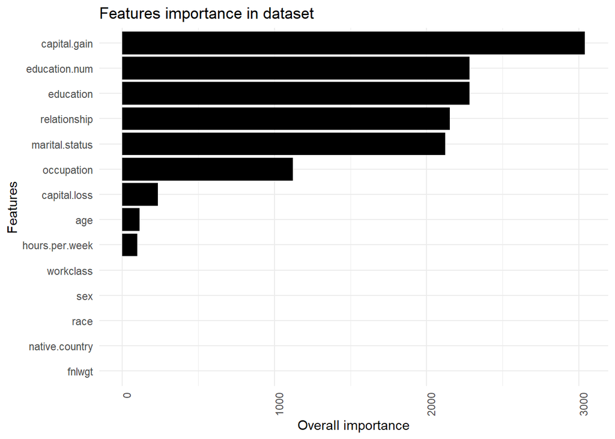

```r
model1<-rpart(income~.,data = trainset)
var1<-varImp(model1) # Calculation of iimportance
var1<-rownames_to_column(var1) # Transfer of the row names to the separate column in data frame
varImpotance<-var1[order(-var1$Overall),] # Reorder of the importances by value
ggplot(varImpotance,aes(x = reorder(rowname, Overall),y=Overall),fill = variable)+ #chart creation
  geom_bar(stat = "identity",fill="black")+
  xlab("Features")+ylab("Overall importance")+ggtitle("Features importance in dataset")+
  theme_minimal()+ theme(axis.text.x = element_text(angle = 90, hjust = 1))+coord_flip()
```

```r
trainset_opt<-trainset%>%select(-workclass,-sex, -race, -native.country,-fnlwgt,-hours.per.week,-age)
as_tibble(trainset_opt)%>%head(n=10)%>%kable() %>%
  kable_styling(bootstrap_options = c("striped", "hover", "condensed"))
```

| education | education.num | marital.status | occupation | relationship | capital.gain | capital.loss | income |
| --- | --- | --- | --- | --- | --- | --- | --- |
| HS-grad | 9 | Widowed | ? | Not-in-family | 0 | 4356 | <=50K |
| HS-grad | 9 | Widowed | Exec-managerial | Not-in-family | 0 | 4356 | <=50K |
| Some-college | 10 | Widowed | ? | Unmarried | 0 | 4356 | <=50K |
| 7th-8th | 4 | Divorced | Machine-op-inspct | Unmarried | 0 | 3900 | <=50K |
| Some-college | 10 | Separated | Prof-specialty | Own-child | 0 | 3900 | <=50K |
| HS-grad | 9 | Divorced | Other-service | Unmarried | 0 | 3770 | <=50K |
| 10th | 6 | Separated | Adm-clerical | Unmarried | 0 | 3770 | <=50K |
| Doctorate | 16 | Never-married | Prof-specialty | Other-relative | 0 | 3683 | >50K |
| HS-grad | 9 | Divorced | Prof-specialty | Not-in-family | 0 | 3683 | <=50K |
| Some-college | 10 | Never-married | Craft-repair | Unmarried | 0 | 3004 | >50K |

For all training model was used the same method of cross validation with 5 folds with parallel processing on 7 cores of desktop Below first try is to use random forest algoriithm with parallel processing with parameter selection Duration of theh process with 7 parallel cores is ca 10 minutes

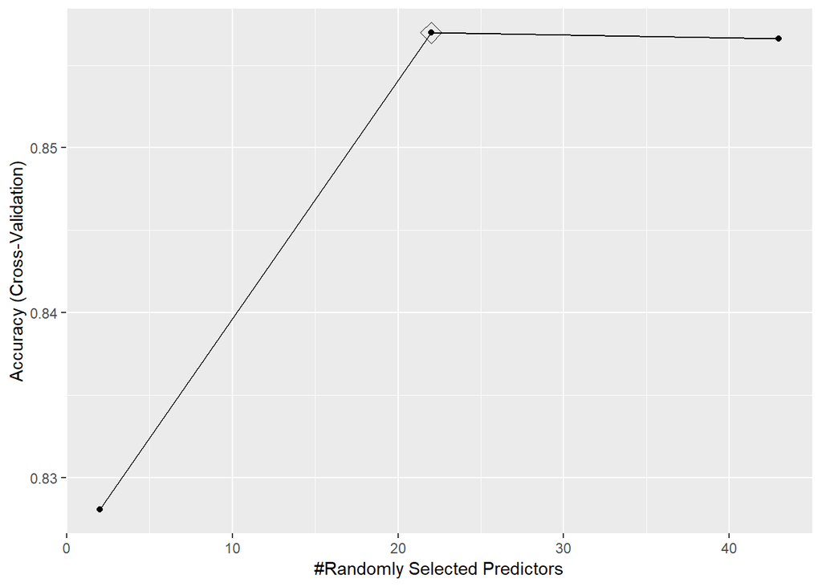

```r
tsCVstart<-Sys.time()
#print(paste("Process started",tsCVstart))
cluster <- makeCluster(detectCores() - 1) # convention to leave 1 core for OS
registerDoParallel(cluster)  # registration of the clusters for parallel processing
fitControl <- trainControl(method = "cv",
                           number = 5,
                           allowParallel = TRUE) # adjusting control for allowing parrallel processing
set.seed(1)
model_rf<-train(income~., method="rf",data = trainset_opt,trControl = fitControl) # creation of the model for all attributes, take a lot of time
#model_rf # display of the model
ggplot(model_rf,highlight = T) # result of optimisation
```

```r
prediction_rf<-predict(model_rf,validation)
#confusionMatrix(data=prediction_rf,reference=validation$income)
stopCluster(cluster)
registerDoSEQ()
accuracy_rf<-confusionMatrix(data=prediction_rf,reference=validation$income)$overall[["Accuracy"]]

accuracy_results <- bind_rows(accuracy_results,
                          data_frame(method="rf ",
                                     Accuracy = accuracy_rf))
print(accuracy_results)
```

```
##   method  Accuracy
## 1    rf  0.8652134
```

```r
tsCVfinish<-Sys.time()
#print(paste("Process finished ",tsCVfinish))
print(paste("Process duration ",trunc(unclass(tsCVfinish)-unclass(tsCVstart)),"sec"))
```

```
## [1] "Process duration  483 sec"
```

Second model for the training was selected xgbTree method from caret package. Method xgbTree is one of the methods of xgBoosting and is supposed for classification

```r
getModelInfo()$xgbTree$type
```

```
## [1] "Regression"     "Classification"
```

Calculation will take approximately 2 minutes with 7 cores

```r
tsCVstart<-Sys.time()
#print(paste("Process started",tsCVstart))
cluster <- makeCluster(detectCores() - 1) # convention to leave 1 core for OS
registerDoParallel(cluster)  # registration of the clusters for parallel processing
fitControl <- trainControl(method = "cv",
                           number = 5,
                           allowParallel = TRUE) # adjusting control for allowing parrallel processing
set.seed(1)
model_xgbTree<-train(income~., method="xgbTree",data = trainset_opt,trControl = fitControl) # creation of the model for all attributes, take a lot of time
#model_xgbTree # display of the model
#ggplot(model_xgbTree,highlight = T)
prediction_xgbTree<-predict(model_xgbTree,validation)
#confusionMatrix(data=prediction_xgbTree,reference=validation$income)
stopCluster(cluster)
registerDoSEQ()
accuracy_xgbTree<-confusionMatrix(data=prediction_xgbTree,reference=validation$income)$overall[["Accuracy"]]

accuracy_results <- bind_rows(accuracy_results,
                          data_frame(method="xgbTree ",
                                     Accuracy = accuracy_xgbTree))
print(accuracy_results)
```

```
##     method  Accuracy
## 1      rf  0.8652134
## 2 xgbTree  0.8698189
```

```r
tsCVfinish<-Sys.time()
#print(paste("Process finished ",tsCVfinish))
print(paste("Process duration ",trunc(unclass(tsCVfinish)-unclass(tsCVstart)),"sec"))
```

```
## [1] "Process duration  110 sec"
```

Third methon was taken very popular method of xgbDart Method xgbDART is XGBoost method and is supposed for classification

```r
getModelInfo()$xgbDART$type
```

```
## [1] "Regression"     "Classification"
```

Calculation will take approximately 16 minutes with 7 cores

```r
tsCVstart<-Sys.time()
#print(paste("Process started",tsCVstart))
cluster <- makeCluster(detectCores() - 1) # convention to leave 1 core for OS
registerDoParallel(cluster)  # registration of the clusters for parallel processing
fitControl <- trainControl(method = "cv",
                           number = 5,
                           allowParallel = TRUE) # adjusting control for allowing parrallel processing
set.seed(1)
model_xgbDART<-train(income~., method="xgbDART",data = trainset_opt,trControl = fitControl) # creation of the model for all attributes, take a lot of time
#model_xgbDART # display of the model
#ggplot(model_xgbDART,highlight = T)
prediction_xgbDART<-predict(model_xgbDART,validation)
#confusionMatrix(data=prediction_xgbDART,reference=validation$income)
stopCluster(cluster)
registerDoSEQ()
accuracy_xgbDART<-confusionMatrix(data=prediction_xgbDART,reference=validation$income)$overall[["Accuracy"]]

accuracy_results <- bind_rows(accuracy_results,
                          data_frame(method="xgbDART ",
                                     Accuracy = accuracy_xgbDART))
print(accuracy_results)
```

```
##     method  Accuracy
## 1      rf  0.8652134
## 2 xgbTree  0.8698189
## 3 xgbDART  0.8725821
```

```r
tsCVfinish<-Sys.time()
#print(paste("Process finished ",tsCVfinish))
print(paste("Process duration ",trunc(unclass(tsCVfinish)-unclass(tsCVstart)),"sec"))
```

```
## [1] "Process duration  825 sec"
```

Training model with logistic regression (glm method in cated package) Method glm is logistic regression model and is supposed for classification

```r
getModelInfo()$glm$type
```

```
## [1] "Regression"     "Classification"
```

Calculation will take approximately 0.5 minutes with 7 cores

```r
tsCVstart<-Sys.time()
#print(paste("Process started",tsCVstart))
cluster <- makeCluster(detectCores() - 1) # convention to leave 1 core for OS
registerDoParallel(cluster)  # registration of the clusters for parallel processing
fitControl <- trainControl(method = "cv",
                           number = 5,
                           allowParallel = TRUE) # adjusting control for allowing parrallel processing
set.seed(1)
model_glm<-train(income~., method="glm",data = trainset_opt,trControl = fitControl) # creation of the model for all attributes, take a lot of time
```

```r
#model_glm # display of the model
#ggplot(model_glm,highlight = T)
prediction_glm<-predict(model_glm,validation)
#confusionMatrix(data=prediction_glm,reference=validation$income)
stopCluster(cluster)
registerDoSEQ()
accuracy_glm<-confusionMatrix(data=prediction_glm,reference=validation$income)$overall[["Accuracy"]]

accuracy_results <- bind_rows(accuracy_results,
                          data_frame(method="glm",
                                     Accuracy = accuracy_glm))
print(accuracy_results)
```

```
##     method  Accuracy
## 1      rf  0.8652134
## 2 xgbTree  0.8698189
## 3 xgbDART  0.8725821
## 4      glm 0.8507829
```

```r
tsCVfinish<-Sys.time()
#print(paste("Process finished ",tsCVfinish))
print(paste("Process duration ",trunc(unclass(tsCVfinish)-unclass(tsCVstart)),"sec"))
```

```
## [1] "Process duration  25 sec"
```

Training model with Generalized Boosted Regression Modeling Method gbm is Generalized Boosted Regression Modeling (GBM) and is supposed for classification

```r
getModelInfo()$gbm$type
```

```
## [1] "Regression"     "Classification"
```

Calculation will take approximately 1 minutes with 7 cores

```r
tsCVstart<-Sys.time()
#print(paste("Process started",tsCVstart))
cluster <- makeCluster(detectCores() - 1) # convention to leave 1 core for OS
registerDoParallel(cluster)  # registration of the clusters for parallel processing
fitControl <- trainControl(method = "cv",
                           number = 5,
                           allowParallel = TRUE) # adjusting control for allowing parrallel processing
set.seed(1)
model_gbm<-train(income~., method="gbm",data = trainset_opt,trControl = fitControl) # creation of the model for all attributes, take a lot of time
```

```r
#model_gbm # display of the model
#ggplot(model_gbm,highlight = T)
prediction_gbm<-predict(model_gbm,validation)
#confusionMatrix(data=prediction_gbm,reference=validation$income)
stopCluster(cluster)
registerDoSEQ()
accuracy_gbm<-confusionMatrix(data=prediction_rf,reference=validation$income)$overall[["Accuracy"]]

accuracy_results <- bind_rows(accuracy_results,
                          data_frame(method="GBM ",
                                     Accuracy = accuracy_gbm))
print(accuracy_results)
```

```
##     method  Accuracy
## 1      rf  0.8652134
## 2 xgbTree  0.8698189
## 3 xgbDART  0.8725821
## 4      glm 0.8507829
## 5     GBM  0.8652134
```

```r
tsCVfinish<-Sys.time()
#print(paste("Process finished ",tsCVfinish))
print(paste("Process duration ",trunc(unclass(tsCVfinish)-unclass(tsCVstart)),"sec"))
```

```
## [1] "Process duration  47 sec"
```

Training model with LogitBoost LogitBoost is Boostet Logistic regression models and is supposed for classification

```r
getModelInfo()$LogitBoost$type
```

```
## [1] "Classification"
```

LogitBoost

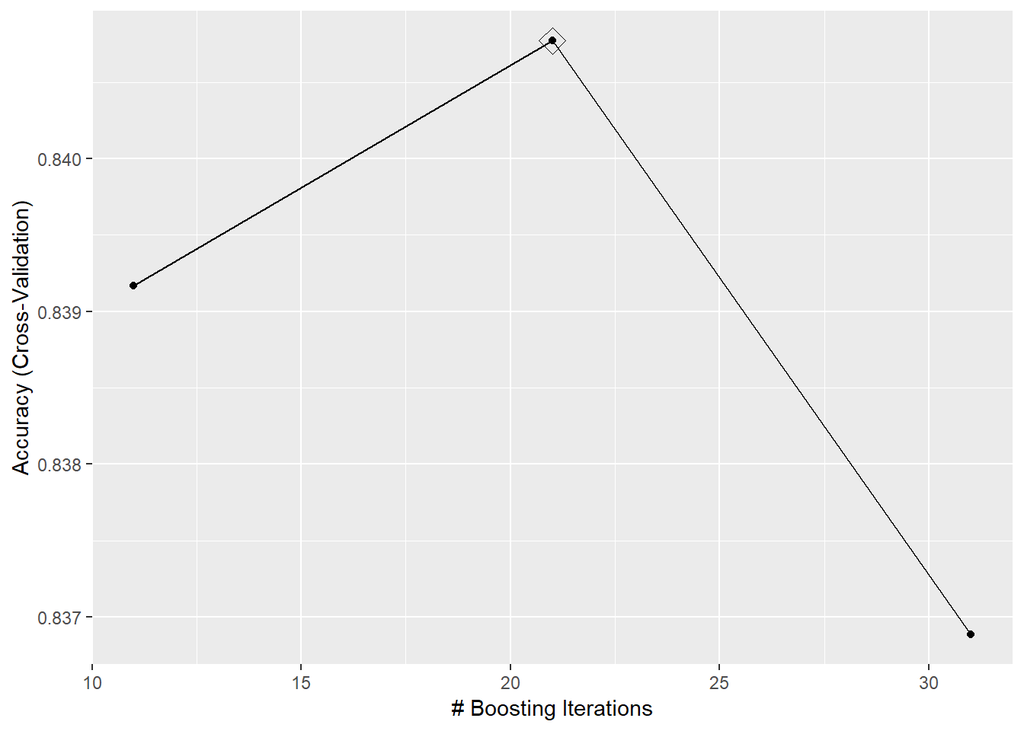

```r
tsCVstart<-Sys.time()
#print(paste("Process started",tsCVstart))
cluster <- makeCluster(detectCores() - 1) # convention to leave 1 core for OS
registerDoParallel(cluster)  # registration of the clusters for parallel processing
fitControl <- trainControl(method = "cv",
                           number = 5,
                           allowParallel = TRUE) # adjusting control for allowing parrallel processing
set.seed(1)
model_LogitBoost<-train(income~., method="LogitBoost",data = trainset_opt,trControl = fitControl) # creation of the model for all attributes, take a lot of time
#model_LogitBoost # display of the model
ggplot(model_LogitBoost,highlight = T)
```

```r
prediction_LogitBoost<-predict(model_LogitBoost,validation)
#confusionMatrix(data=prediction_LogitBoost,reference=validation$income)
stopCluster(cluster)
registerDoSEQ()
accuracy_LogitBoost<-confusionMatrix(data=prediction_rf,reference=validation$income)$overall[["Accuracy"]]

accuracy_results <- bind_rows(accuracy_results,
                          data_frame(method="LogitBoost ",
                                     Accuracy = accuracy_LogitBoost))

tsCVfinish<-Sys.time()
#print(paste("Process finished ",tsCVfinish))
print(paste("Process duration ",trunc(unclass(tsCVfinish)-unclass(tsCVstart)),"sec"))
```

```
## [1] "Process duration  26 sec"
```

# Results section

```r
print(accuracy_results)%>%kable() %>%
  kable_styling(bootstrap_options = c("striped", "hover", "condensed"))
```

```
##        method  Accuracy
## 1         rf  0.8652134
## 2    xgbTree  0.8698189
## 3    xgbDART  0.8725821
## 4         glm 0.8507829
## 5        GBM  0.8652134
## 6 LogitBoost  0.8652134
```

| method | Accuracy |
| --- | --- |
| rf | 0.8652134 |
| xgbTree | 0.8698189 |
| xgbDART | 0.8725821 |
| glm | 0.8507829 |
| GBM | 0.8652134 |
| LogitBoost | 0.8652134 |

# Conclusion section.